# HW 12 regression in r

Problem 2

Alumno: Daniel Nuño, daniel.nuno@iteso.mx

Alumno: David Cisneros

Alumno: Juan Maro Ochoa

Alumno: Rodrigo Huerta

4/18/2022

# Problem 2: Application Problems

Note that some details are missing for all the following examples, the problems lack a complete explanation, and the code may need adequate comments. In this form, you must present a proper mathematical formulation, a brief background of the problem (and its bibliographical references) and, a much better explanation.

- The olsrr packeage
  1. [Introduction to olsrr](https://olsrr.rsquaredacademy.com/articles/intro.html)
  2. [Variable Selection Methods](https://olsrr.rsquaredacademy.com/articles/variable_selection.html)
  3. [Residual Diagnostics](https://olsrr.rsquaredacademy.com/articles/residual_diagnostics.html)
  4. [Heteroscedasticity](https://olsrr.rsquaredacademy.com/articles/heteroskedasticity.html)
  5. [Measures of Influence](https://olsrr.rsquaredacademy.com/articles/influence_measures.html)
  6. [Collinearity Diagnostics, Model Fit & Variable Contribution](https://olsrr.rsquaredacademy.com/articles/regression_diagnostics.html)
- The blorr package
  1. [A Short Introduction to the blorr Package](https://blorr.rsquaredacademy.com/articles/introduction.html)

## Introduction to olsrr

This document is a quick start guide to the tools offered by olsrr. Other vignettes provide more details on specific topics: - Residual Diagnostics: Includes plots to examine residuals to validate OLS assumptions - Variable selection: Different variable selection procedures such as all possible regression, best subset regression, stepwise regression, stepwise forward regression and stepwise backward regression - Heteroskedasticity: Tests for heteroskedasticity include bartlett test, breusch pagan test, score test and f test - Measures of influence: Includes 10 different plots to detect and identify influential observations - Collinearity diagnostics: VIF, Tolerance and condition indices to detect collinearity and plots for assessing mode fit and contributions of variables

### Regression

```r
library(olsrr)
ols_regress(mpg ~ disp + hp + wt + qsec, data = mtcars)
```

```
                         Model Summary
---------------------------------------------------------------
R                       0.914       RMSE                 2.409
R-Squared               0.835       MSE                  6.875
Adj. R-Squared          0.811       Coef. Var           13.051
Pred R-Squared          0.771       AIC                159.070
MAE                     1.858       SBC                167.864
---------------------------------------------------------------
 RMSE: Root Mean Square Error
 MSE: Mean Square Error
 MAE: Mean Absolute Error
 AIC: Akaike Information Criteria
 SBC: Schwarz Bayesian Criteria

                               ANOVA
--------------------------------------------------------------------
                Sum of
               Squares        DF    Mean Square      F         Sig.
--------------------------------------------------------------------
Regression     940.412         4        235.103    34.195    0.0000
Residual       185.635        27          6.875
Total         1126.047        31
--------------------------------------------------------------------

                                  Parameter Estimates
----------------------------------------------------------------------------------------
      model      Beta    Std. Error    Std. Beta      t        Sig      lower     upper
----------------------------------------------------------------------------------------
(Intercept)    27.330         8.639                  3.164    0.004     9.604    45.055
       disp     0.003         0.011        0.055     0.248    0.806    -0.019     0.025
         hp    -0.019         0.016       -0.212    -1.196    0.242    -0.051     0.013
         wt    -4.609         1.266       -0.748    -3.641    0.001    -7.206    -2.012
       qsec     0.544         0.466        0.161     1.166    0.254    -0.413     1.501
----------------------------------------------------------------------------------------
```

In the presence of interaction terms in the model, the predictors are scaled and centered before computing the standardized betas. `ols_regress()` will detect interaction terms automatically but in case you have created a new variable instead of using the inline function `*`, you can indicate the presence of interaction terms by setting `iterm` to `TRUE`.

### Residual vs Fitted Values Plot

Plot to detect non-linearity, unequal error variances, and outliers. Each point is the error in each vector. Red line just marks the 0 to have a visual benchmark.

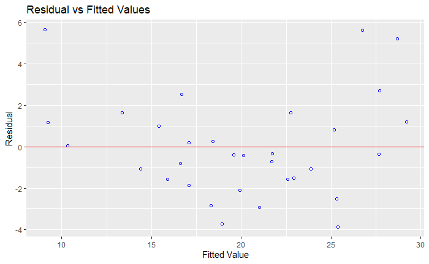

```r
model <- lm(mpg ~ disp + hp + wt + qsec, data = mtcars)
ols_plot_resid_fit(model)
```

### DFBETAs Panel

DFBETAs measure the difference in each parameter estimate with and without the influential observation. `dfbetas_panel` creates plots to detect influential observations using DFBETAs.

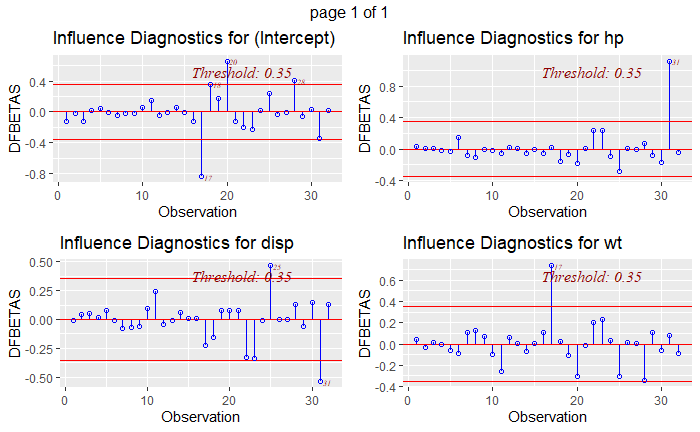

```r
model <- lm(mpg ~ disp + hp + wt, data = mtcars)
ols_plot_dfbetas(model)
```

### Residual Fit Spread Plot

Plot to detect non-linearity, influential observations and outliers.

Each spread plot is a graph of centered data values plotted against the estimated cumulative probability. Thus, spread plots are similar to a (rotated) plot of the empirical cumulative distribution function. [reference](https://blogs.sas.com/content/iml/2013/06/12/interpret-residual-fit-spread-plot.html)

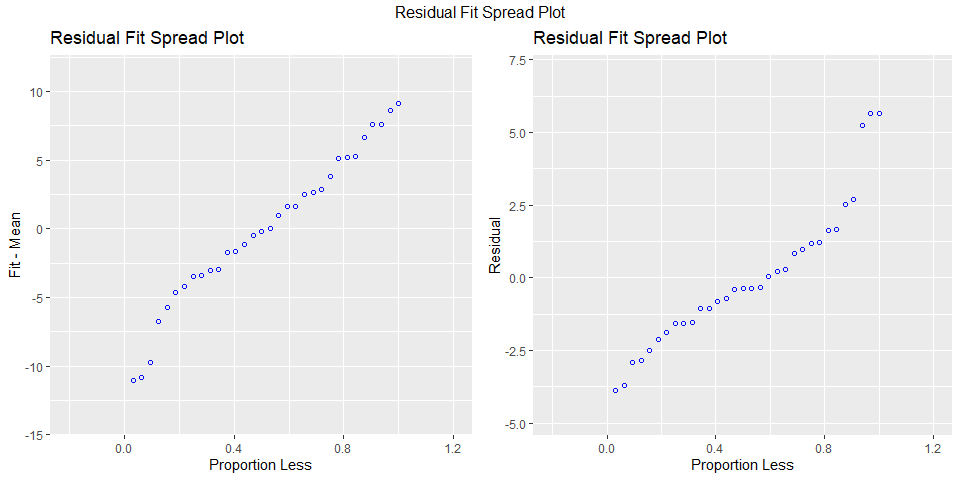

```r
model <- lm(mpg ~ disp + hp + wt + qsec, data = mtcars)
ols_plot_resid_fit_spread(model)
```

### Breusch Pagan Test

Breusch Pagan test is used to test for herteroskedasticity (non-constant error variance). It tests whether the variance of the errors from a regression is dependent on the values of the independent variables. It is a $\chi^{2}$ test.

```r
model <- lm(mpg ~ disp + hp + wt + drat, data = mtcars)
ols_test_breusch_pagan(model)
```

```
 Breusch Pagan Test for Heteroskedasticity
 -----------------------------------------
 Ho: the variance is constant
 Ha: the variance is not constant

             Data
 -------------------------------
 Response : mpg
 Variables: fitted values of mpg

       Test Summary
 ---------------------------
 DF            =    1
 Chi2          =    1.429672
 Prob > Chi2   =    0.231818
```

### Collinearity Diagnostics

collinearity, in statistics, correlation between predictor variables (or independent variables), such that they express a linear relationship in a regression model. When predictor variables in the same regression model are correlated, they cannot independently predict the value of the dependent variable.

```r
model <- lm(mpg ~ disp + hp + wt + qsec, data = mtcars)
ols_coll_diag(model)
```

```
Tolerance and Variance Inflation Factor
---------------------------------------
```

| Variables | Tolerance | VIF |
| --- | --- | --- |
| disp | 0.1252279 | 7.985439 |
| hp | 0.1935450 | 5.166758 |
| wt | 0.1445726 | 6.916942 |
| qsec | 0.3191708 | 3.133119 |

```
Eigenvalue and Condition Index
------------------------------
```

| Eigenvalue | Condition Index | intercept | disp | hp | wt | qsec |
| --- | --- | --- | --- | --- | --- | --- |
| 4.721487187 | 1.000000 | 0.000123237 | 0.001132468 | 0.001413094 | 0.0005253393 | 0.0001277169 |
| 0.216562203 | 4.669260 | 0.002617424 | 0.036811051 | 0.027751289 | 0.0002096014 | 0.0046789491 |
| 0.050416837 | 9.677242 | 0.001656551 | 0.120881424 | 0.392366164 | 0.0377028008 | 0.0001952599 |
| 0.010104757 | 21.616057 | 0.025805998 | 0.777260487 | 0.059594623 | 0.7017528428 | 0.0024577686 |
| 0.001429017 | 57.480524 | 0.969796790 | 0.063914571 | 0.518874831 | 0.2598094157 | 0.9925403056 |

### Stepwise Regression

Build regression model from a set of candidate predictor variables by entering and removing predictors based on p values, in a stepwise manner until there is no variable left to enter or remove any more.

Here p-value and Akaike Information Criterion are used to decide which model is the best in each step of the algorithm.

### Variable Selection

```r
# stepwise regression
model <- lm(y ~ ., data = surgical)
ols_step_both_p(model)
```

```
                                Stepwise Summary
------------------------------------------------------------------------------
Step    Variable             AIC        SBC       SBIC        R2       Adj. R2
------------------------------------------------------------------------------
 0      Base Model         802.606    806.584    646.794    0.00000    0.00000
 1      liver_test (+)     771.875    777.842    616.009    0.45454    0.44405
 2      alc_heavy (+)      761.439    769.395    605.506    0.56674    0.54975
 3      enzyme_test (+)    750.509    760.454    595.297    0.65900    0.63854
 4      pindex (+)         735.715    747.649    582.943    0.75015    0.72975
 5      bcs (+)            730.620    744.543    579.638    0.78091    0.75808
------------------------------------------------------------------------------

Final Model Output
------------------

                           Model Summary
-------------------------------------------------------------------
R                         0.884       RMSE                 184.276
R-Squared                 0.781       MSE                38202.426
Adj. R-Squared            0.758       Coef. Var             27.839
Pred R-Squared            0.700       AIC                  730.620
MAE                     137.656       SBC                  744.543
-------------------------------------------------------------------
 RMSE: Root Mean Square Error
 MSE: Mean Square Error
 MAE: Mean Absolute Error
 AIC: Akaike Information Criteria
 SBC: Schwarz Bayesian Criteria

                                 ANOVA
-----------------------------------------------------------------------
                   Sum of
                  Squares        DF    Mean Square      F         Sig.
-----------------------------------------------------------------------
Regression    6535804.090         5    1307160.818    34.217    0.0000
Residual      1833716.447        48      38202.426
Total         8369520.537        53
-----------------------------------------------------------------------

                                      Parameter Estimates
------------------------------------------------------------------------------------------------
      model         Beta    Std. Error    Std. Beta      t        Sig         lower       upper
------------------------------------------------------------------------------------------------
(Intercept)    -1178.330       208.682                 -5.647    0.000    -1597.914    -758.746
 liver_test       58.064        40.144        0.156     1.446    0.155      -22.652     138.779
  alc_heavy      317.848        71.634        0.314     4.437    0.000      173.818     461.878
enzyme_test        9.748         1.656        0.521     5.887    0.000        6.419      13.077
     pindex        8.924         1.808        0.380     4.935    0.000        5.288      12.559
        bcs       59.864        23.060        0.241     2.596    0.012       13.498     106.230
------------------------------------------------------------------------------------------------
```

### Plot

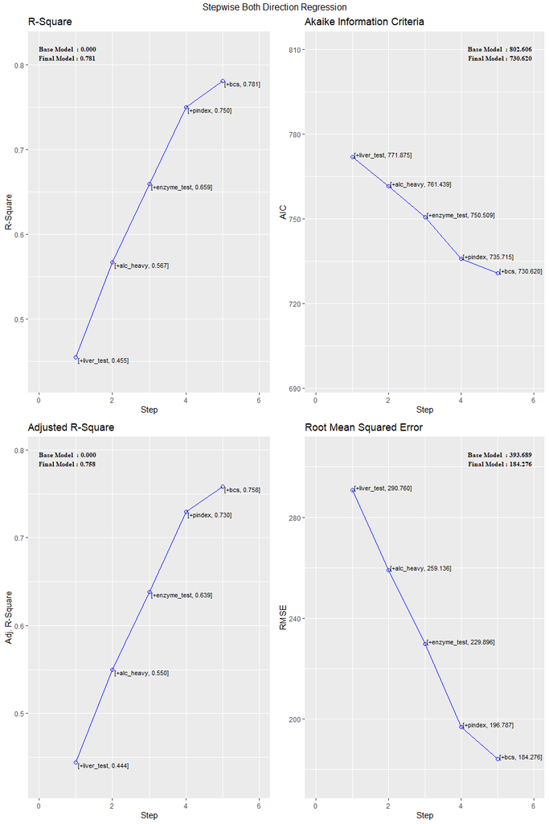

```r
model <- lm(y ~ ., data = surgical)
k <- ols_step_both_p(model)
plot(k)
```

###Stepwise AIC Backward Regression

Build regression model from a set of candidate predictor variables by removing predictors based on Akaike Information Criteria, in a stepwise manner until there is no variable left to remove any more.

###Variable Selection

```r
# stepwise aic backward regression
model <- lm(y ~ ., data = surgical)
k <- ols_step_backward_aic(model)
k
```

```
                             Stepwise Summary
-------------------------------------------------------------------------
Step    Variable        AIC        SBC       SBIC        R2       Adj. R2
-------------------------------------------------------------------------
 0      Full Model    736.390    756.280    586.665    0.78184    0.74305
 1      alc_mod       734.407    752.308    583.884    0.78177    0.74856
 2      gender        732.494    748.406    581.290    0.78142    0.75351
 3      age           730.620    744.543    578.844    0.78091    0.75808
-------------------------------------------------------------------------

Final Model Output
------------------

                           Model Summary
-------------------------------------------------------------------
R                         0.884       RMSE                 184.276
R-Squared                 0.781       MSE                38202.426
Adj. R-Squared            0.758       Coef. Var             27.839
Pred R-Squared            0.700       AIC                  730.620
MAE                     137.656       SBC                  744.543
-------------------------------------------------------------------
 RMSE: Root Mean Square Error
 MSE: Mean Square Error
 MAE: Mean Absolute Error
 AIC: Akaike Information Criteria
 SBC: Schwarz Bayesian Criteria

                                 ANOVA
-----------------------------------------------------------------------
                   Sum of
                  Squares        DF    Mean Square      F         Sig.
-----------------------------------------------------------------------
Regression    6535804.090         5    1307160.818    34.217    0.0000
Residual      1833716.447        48      38202.426
Total         8369520.537        53
-----------------------------------------------------------------------

                                      Parameter Estimates
------------------------------------------------------------------------------------------------
      model         Beta    Std. Error    Std. Beta      t        Sig         lower       upper
------------------------------------------------------------------------------------------------
(Intercept)    -1178.330       208.682                 -5.647    0.000    -1597.914    -758.746
        bcs       59.864        23.060        0.241     2.596    0.012       13.498     106.230
     pindex        8.924         1.808        0.380     4.935    0.000        5.288      12.559
enzyme_test        9.748         1.656        0.521     5.887    0.000        6.419      13.077
 liver_test       58.064        40.144        0.156     1.446    0.155      -22.652     138.779
  alc_heavy      317.848        71.634        0.314     4.437    0.000      173.818     461.878
------------------------------------------------------------------------------------------------
```

### Plot

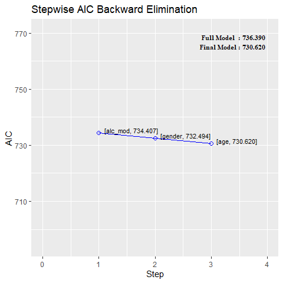

```r
model <- lm(y ~ ., data = surgical)
k <- ols_step_backward_aic(model)
plot(k)
```

## Variable Selection Methods

### All Possible Regression

All subset regression tests, all possible subsets of the set of potential independent variables. If there are K potential independent variables (besides the constant), then there are $2^{k}$ distinct subsets of them to be tested. For example, if you have 10 candidate independent variables, the number of subsets to be tested is $2^{10}$, which is 1024, and if you have 20 candidate variables, the number is $2^{20}$, which is more than one million.

```r
model <- lm(mpg ~ disp + hp + wt + qsec, data = mtcars)
ols_step_all_possible(model)
```

[output not shown]

[output cut: 5 more lines]

The `plot` method shows the panel of fit criteria for all possible regression methods.

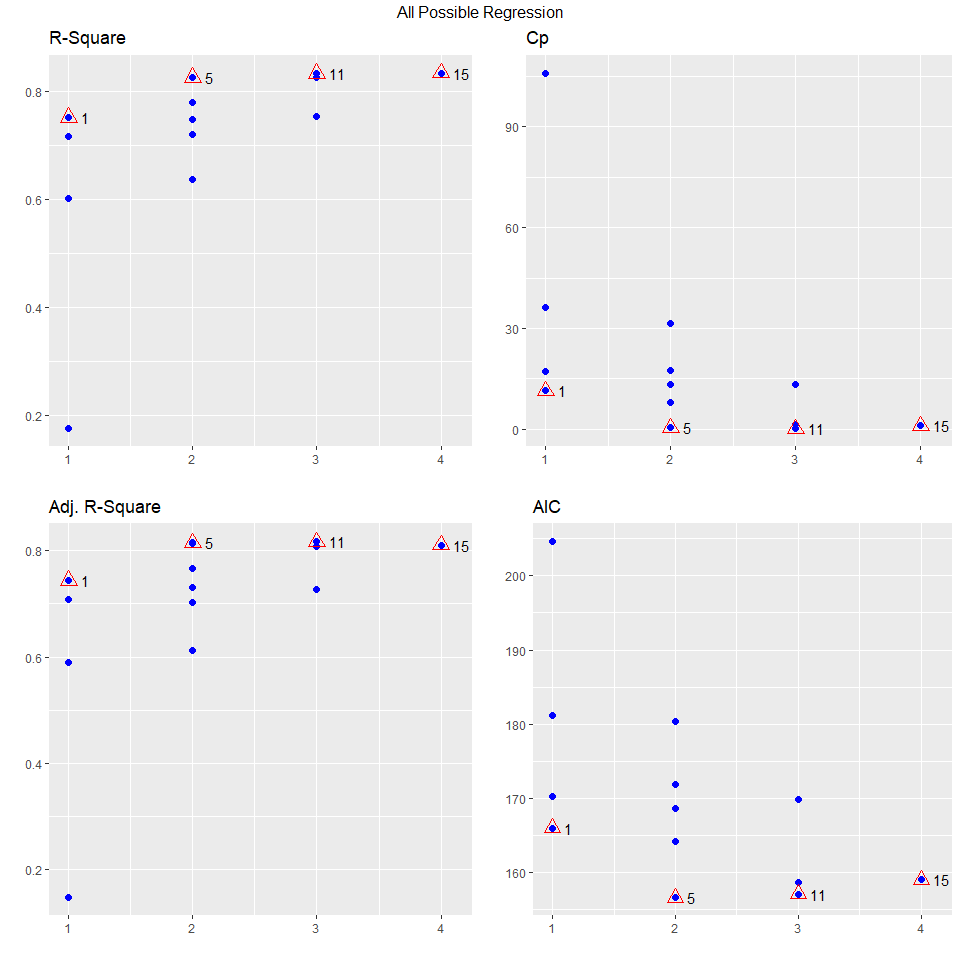

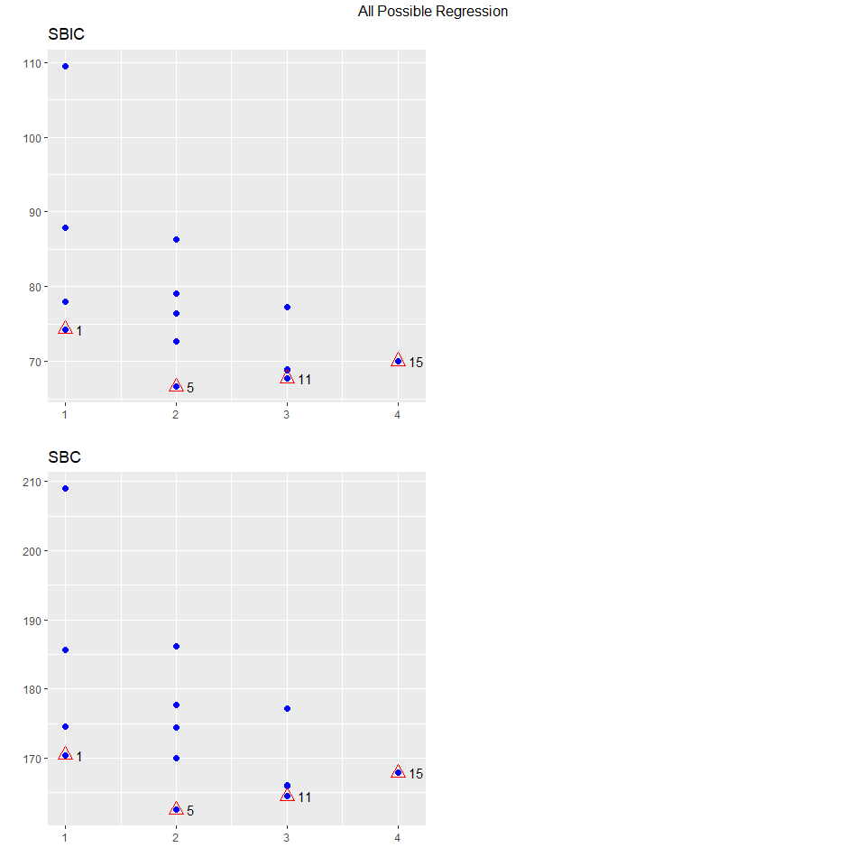

```r
model <- lm(mpg ~ disp + hp + wt + qsec, data = mtcars)
k <- ols_step_all_possible(model)
plot(k)
```

### Best Subset Regression

Select the subset of predictors that do the best at meeting some well-defined objective criterion, such as having the largest R2 value or the smallest MSE, Mallow’s Cp or AIC.

```r
model <- lm(mpg ~ disp + hp + wt + qsec, data = mtcars)
ols_step_best_subset(model)
```

```
   Best Subsets Regression
------------------------------
Model Index    Predictors
------------------------------
     1         wt
     2         hp wt
     3         hp wt qsec
     4         disp hp wt qsec
------------------------------

                                                   Subsets Regression Summary
---------------------------------------------------------------------------------------------------------------------------------
                       Adj.        Pred
Model    R-Square    R-Square    R-Square     C(p)        AIC        SBIC        SBC         MSEP       FPE       HSP       APC
---------------------------------------------------------------------------------------------------------------------------------
  1        0.7528      0.7446      0.7087    12.4809    166.0294    74.2916    170.4266    296.9167    9.8572    0.3199    0.2801
  2        0.8268      0.8148      0.7811     2.3690    156.6523    66.5755    162.5153    215.5104    7.3563    0.2402    0.2091
  3        0.8348      0.8171       0.782     3.0617    157.1426    67.7238    164.4713    213.1929    7.4756    0.2461    0.2124
  4        0.8351      0.8107       0.771     5.0000    159.0696    70.0408    167.8640    220.8882    7.9497    0.2644    0.2259
---------------------------------------------------------------------------------------------------------------------------------
AIC: Akaike Information Criteria
 SBIC: Sawa's Bayesian Information Criteria
 SBC: Schwarz Bayesian Criteria
 MSEP: Estimated error of prediction, assuming multivariate normality
 FPE: Final Prediction Error
 HSP: Hocking's Sp
 APC: Amemiya Prediction Criteria
```

The `plot` method shows the panel of fit criteria for best subset regression methods.

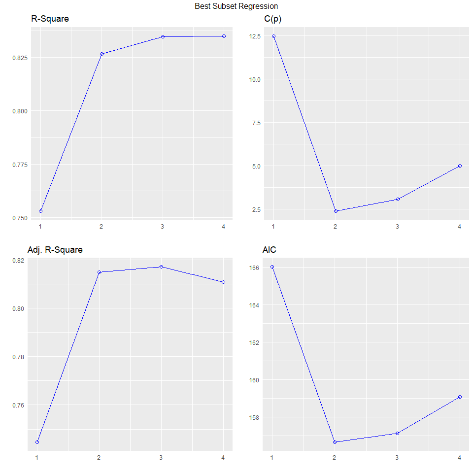

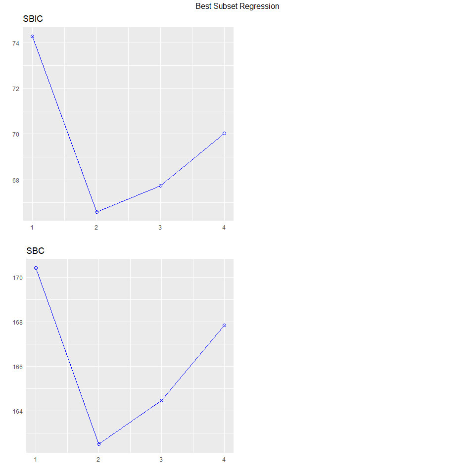

```r
model <- lm(mpg ~ disp + hp + wt + qsec, data = mtcars)
k <- ols_step_best_subset(model)
plot(k)
```

### Stepwise Forward Regression

Build regression model from a set of candidate predictor variables by entering predictors based on p values, in a stepwise manner until there is no variable left to enter any more. The model should include all the candidate predictor variables. If details is set to `TRUE`, each step is displayed.

##### Variable Selection

```r
# stepwise forward regression
model <- lm(y ~ ., data = surgical)
ols_step_forward_p(model)
```

```
                              Stepwise Summary
--------------------------------------------------------------------------
Step    Variable         AIC        SBC       SBIC        R2       Adj. R2
--------------------------------------------------------------------------
 0      Base Model     802.606    806.584    646.794    0.00000    0.00000
 1      liver_test     771.875    777.842    616.009    0.45454    0.44405
 2      alc_heavy      761.439    769.395    605.506    0.56674    0.54975
 3      enzyme_test    750.509    760.454    595.297    0.65900    0.63854
 4      pindex         735.715    747.649    582.943    0.75015    0.72975
 5      bcs            730.620    744.543    579.638    0.78091    0.75808
--------------------------------------------------------------------------

Final Model Output
------------------

                           Model Summary
-------------------------------------------------------------------
R                         0.884       RMSE                 184.276
R-Squared                 0.781       MSE                38202.426
Adj. R-Squared            0.758       Coef. Var             27.839
Pred R-Squared            0.700       AIC                  730.620
MAE                     137.656       SBC                  744.543
-------------------------------------------------------------------
 RMSE: Root Mean Square Error
 MSE: Mean Square Error
 MAE: Mean Absolute Error
 AIC: Akaike Information Criteria
 SBC: Schwarz Bayesian Criteria

                                 ANOVA
-----------------------------------------------------------------------
                   Sum of
                  Squares        DF    Mean Square      F         Sig.
-----------------------------------------------------------------------
Regression    6535804.090         5    1307160.818    34.217    0.0000
Residual      1833716.447        48      38202.426
Total         8369520.537        53
-----------------------------------------------------------------------

                                      Parameter Estimates
------------------------------------------------------------------------------------------------
      model         Beta    Std. Error    Std. Beta      t        Sig         lower       upper
------------------------------------------------------------------------------------------------
(Intercept)    -1178.330       208.682                 -5.647    0.000    -1597.914    -758.746
 liver_test       58.064        40.144        0.156     1.446    0.155      -22.652     138.779
  alc_heavy      317.848        71.634        0.314     4.437    0.000      173.818     461.878
enzyme_test        9.748         1.656        0.521     5.887    0.000        6.419      13.077
     pindex        8.924         1.808        0.380     4.935    0.000        5.288      12.559
        bcs       59.864        23.060        0.241     2.596    0.012       13.498     106.230
------------------------------------------------------------------------------------------------
```

#### Plot

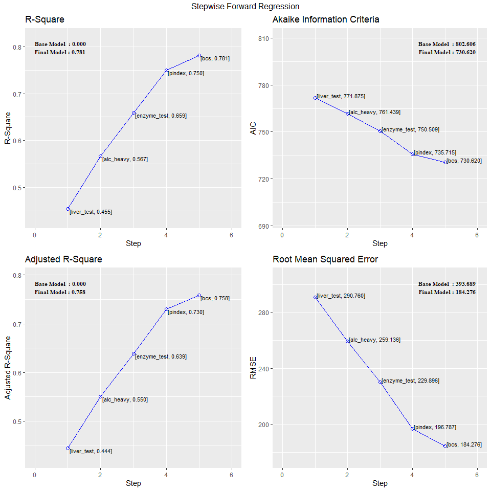

```r
model <- lm(y ~ ., data = surgical)
k <- ols_step_forward_p(model)
plot(k)
```

#### Detailed Output

```r
# stepwise forward regression
model <- lm(y ~ ., data = surgical)
ols_step_forward_p(model, details = TRUE)
```

```
Forward Selection Method
------------------------

Candidate Terms:

1. bcs
2. pindex
3. enzyme_test
4. liver_test
5. age
6. gender
7. alc_mod
8. alc_heavy


Step   => 0
Model  => y ~ 1
R2     => 0

Initiating stepwise selection...

                     Selection Metrics Table
-----------------------------------------------------------------
Predictor      Pr(>|t|)    R-Squared    Adj. R-Squared      AIC
-----------------------------------------------------------------
liver_test      0.00000        0.455             0.444    771.875
enzyme_test     0.00000        0.334             0.322    782.629
pindex          0.00155        0.177             0.161    794.100
alc_heavy       0.00172        0.174             0.158    794.301
bcs             0.01025        0.120             0.103    797.697
alc_mod         0.19286        0.032             0.014    802.828
gender          0.20972        0.030             0.011    802.956
age             0.39073        0.014            -0.005    803.834
-----------------------------------------------------------------

Step      => 1
Selected  => liver_test
Model     => y ~ liver_test
R2        => 0.455

```

[output cut: 121 more lines]

```
Residual      1833716.447        48      38202.426
Total         8369520.537        53
-----------------------------------------------------------------------

                                      Parameter Estimates
------------------------------------------------------------------------------------------------
      model         Beta    Std. Error    Std. Beta      t        Sig         lower       upper
------------------------------------------------------------------------------------------------
(Intercept)    -1178.330       208.682                 -5.647    0.000    -1597.914    -758.746
 liver_test       58.064        40.144        0.156     1.446    0.155      -22.652     138.779
  alc_heavy      317.848        71.634        0.314     4.437    0.000      173.818     461.878
enzyme_test        9.748         1.656        0.521     5.887    0.000        6.419      13.077
     pindex        8.924         1.808        0.380     4.935    0.000        5.288      12.559
        bcs       59.864        23.060        0.241     2.596    0.012       13.498     106.230
------------------------------------------------------------------------------------------------
```

### Stepwise Backward Regression

Build regression model from a set of candidate predictor variables by removing predictors based on p values, in a stepwise manner until there is no variable left to remove any more. The model should include all the candidate predictor variables. If details is set to `TRUE`, each step is displayed.

#### Variable Selection

```r
# stepwise backward regression
model <- lm(y ~ ., data = surgical)
ols_step_backward_p(model)
```

```
                             Stepwise Summary
-------------------------------------------------------------------------
Step    Variable        AIC        SBC       SBIC        R2       Adj. R2
-------------------------------------------------------------------------
 0      Full Model    736.390    756.280    586.665    0.78184    0.74305
 1      alc_mod       734.407    752.308    584.276    0.78177    0.74856
 2      gender        732.494    748.406    581.938    0.78142    0.75351
 3      age           730.620    744.543    579.638    0.78091    0.75808
-------------------------------------------------------------------------

Final Model Output
------------------

                           Model Summary
-------------------------------------------------------------------
R                         0.884       RMSE                 184.276
R-Squared                 0.781       MSE                38202.426
Adj. R-Squared            0.758       Coef. Var             27.839
Pred R-Squared            0.700       AIC                  730.620
MAE                     137.656       SBC                  744.543
-------------------------------------------------------------------
 RMSE: Root Mean Square Error
 MSE: Mean Square Error
 MAE: Mean Absolute Error
 AIC: Akaike Information Criteria
 SBC: Schwarz Bayesian Criteria

                                 ANOVA
-----------------------------------------------------------------------
                   Sum of
                  Squares        DF    Mean Square      F         Sig.
-----------------------------------------------------------------------
Regression    6535804.090         5    1307160.818    34.217    0.0000
Residual      1833716.447        48      38202.426
Total         8369520.537        53
-----------------------------------------------------------------------

                                      Parameter Estimates
------------------------------------------------------------------------------------------------
      model         Beta    Std. Error    Std. Beta      t        Sig         lower       upper
------------------------------------------------------------------------------------------------
(Intercept)    -1178.330       208.682                 -5.647    0.000    -1597.914    -758.746
        bcs       59.864        23.060        0.241     2.596    0.012       13.498     106.230
     pindex        8.924         1.808        0.380     4.935    0.000        5.288      12.559
enzyme_test        9.748         1.656        0.521     5.887    0.000        6.419      13.077
 liver_test       58.064        40.144        0.156     1.446    0.155      -22.652     138.779
  alc_heavy      317.848        71.634        0.314     4.437    0.000      173.818     461.878
------------------------------------------------------------------------------------------------
```

#### Plot

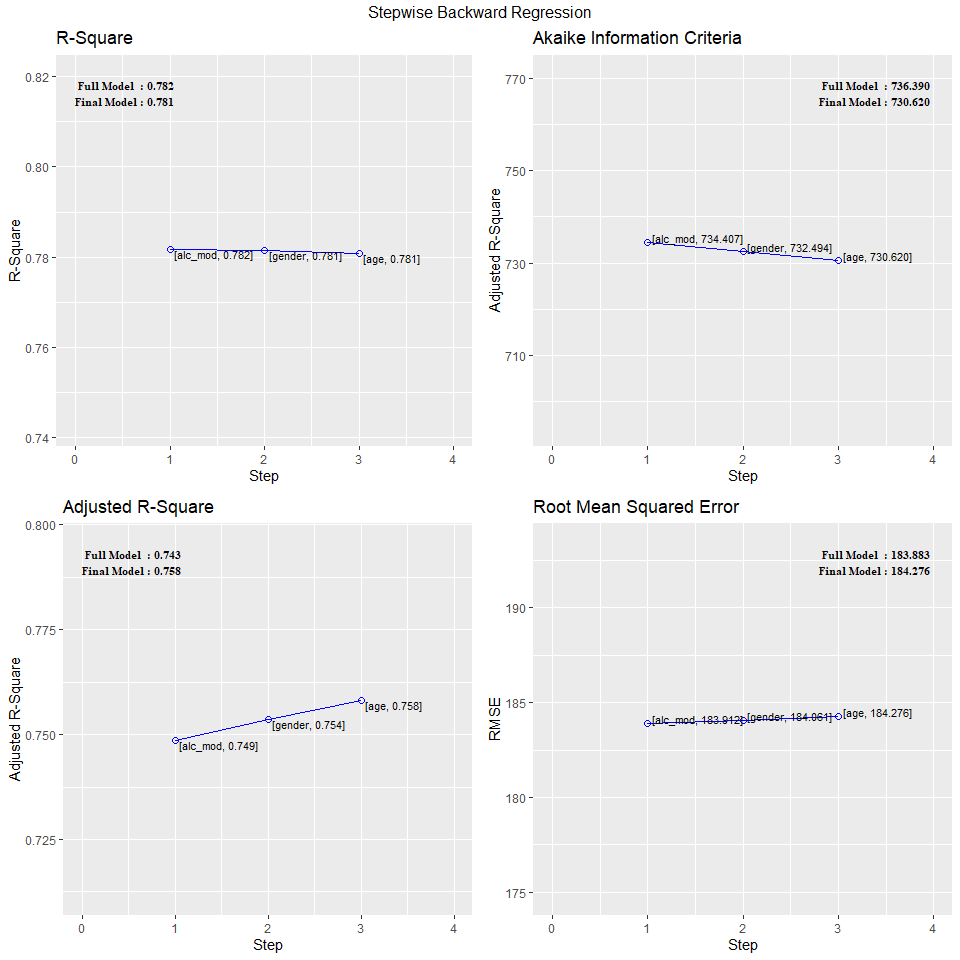

```r
model <- lm(y ~ ., data = surgical)
k <- ols_step_backward_p(model)
plot(k)
```

#### Detailed Output

```r
# stepwise backward regression
model <- lm(y ~ ., data = surgical)
ols_step_backward_p(model, details = TRUE)
```

```
Backward Elimination Method
---------------------------

Candidate Terms:

1. bcs
2. pindex
3. enzyme_test
4. liver_test
5. age
6. gender
7. alc_mod
8. alc_heavy


Step   => 0
Model  => y ~ bcs + pindex + enzyme_test + liver_test + age + gender + alc_mod + alc_heavy
R2     => 0.782

Initiating stepwise selection...

Step     => 1
Removed  => alc_mod
Model    => y ~ bcs + pindex + enzyme_test + liver_test + age + gender + alc_heavy
R2       => 0.78177

Step     => 2
Removed  => gender
Model    => y ~ bcs + pindex + enzyme_test + liver_test + age + alc_heavy
R2       => 0.78142

Step     => 3
Removed  => age
Model    => y ~ bcs + pindex + enzyme_test + liver_test + alc_heavy
R2       => 0.78091


No more variables to be removed.

Variables Removed:
```

[output cut: 38 more lines]

```
Residual      1833716.447        48      38202.426
Total         8369520.537        53
-----------------------------------------------------------------------

                                      Parameter Estimates
------------------------------------------------------------------------------------------------
      model         Beta    Std. Error    Std. Beta      t        Sig         lower       upper
------------------------------------------------------------------------------------------------
(Intercept)    -1178.330       208.682                 -5.647    0.000    -1597.914    -758.746
        bcs       59.864        23.060        0.241     2.596    0.012       13.498     106.230
     pindex        8.924         1.808        0.380     4.935    0.000        5.288      12.559
enzyme_test        9.748         1.656        0.521     5.887    0.000        6.419      13.077
 liver_test       58.064        40.144        0.156     1.446    0.155      -22.652     138.779
  alc_heavy      317.848        71.634        0.314     4.437    0.000      173.818     461.878
------------------------------------------------------------------------------------------------
```

### Stepwise Regression

Build regression model from a set of candidate predictor variables by entering and removing predictors based on p values, in a stepwise manner until there is no variable left to enter or remove any more. The model should include all the candidate predictor variables. If details is set to `TRUE`, each step is displayed.

#### Variable Selection

```r
# stepwise regression
model <- lm(y ~ ., data = surgical)
ols_step_both_p(model)
```

```
                                Stepwise Summary
------------------------------------------------------------------------------
Step    Variable             AIC        SBC       SBIC        R2       Adj. R2
------------------------------------------------------------------------------
 0      Base Model         802.606    806.584    646.794    0.00000    0.00000
 1      liver_test (+)     771.875    777.842    616.009    0.45454    0.44405
 2      alc_heavy (+)      761.439    769.395    605.506    0.56674    0.54975
 3      enzyme_test (+)    750.509    760.454    595.297    0.65900    0.63854
 4      pindex (+)         735.715    747.649    582.943    0.75015    0.72975
 5      bcs (+)            730.620    744.543    579.638    0.78091    0.75808
------------------------------------------------------------------------------

Final Model Output
------------------

                           Model Summary
-------------------------------------------------------------------
R                         0.884       RMSE                 184.276
R-Squared                 0.781       MSE                38202.426
Adj. R-Squared            0.758       Coef. Var             27.839
Pred R-Squared            0.700       AIC                  730.620
MAE                     137.656       SBC                  744.543
-------------------------------------------------------------------
 RMSE: Root Mean Square Error
 MSE: Mean Square Error
 MAE: Mean Absolute Error
 AIC: Akaike Information Criteria
 SBC: Schwarz Bayesian Criteria

                                 ANOVA
-----------------------------------------------------------------------
                   Sum of
                  Squares        DF    Mean Square      F         Sig.
-----------------------------------------------------------------------
Regression    6535804.090         5    1307160.818    34.217    0.0000
Residual      1833716.447        48      38202.426
Total         8369520.537        53
-----------------------------------------------------------------------

                                      Parameter Estimates
------------------------------------------------------------------------------------------------
      model         Beta    Std. Error    Std. Beta      t        Sig         lower       upper
------------------------------------------------------------------------------------------------
(Intercept)    -1178.330       208.682                 -5.647    0.000    -1597.914    -758.746
 liver_test       58.064        40.144        0.156     1.446    0.155      -22.652     138.779
  alc_heavy      317.848        71.634        0.314     4.437    0.000      173.818     461.878
enzyme_test        9.748         1.656        0.521     5.887    0.000        6.419      13.077
     pindex        8.924         1.808        0.380     4.935    0.000        5.288      12.559
        bcs       59.864        23.060        0.241     2.596    0.012       13.498     106.230
------------------------------------------------------------------------------------------------
```

#### Plot

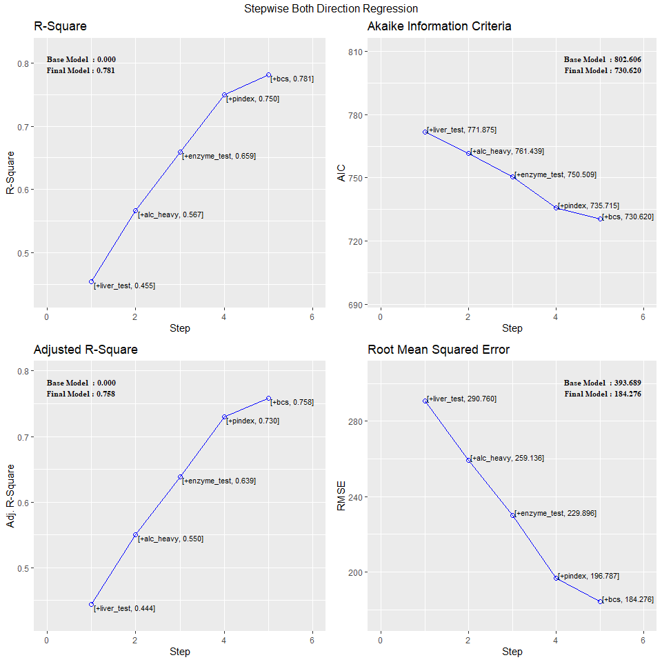

```r
model <- lm(y ~ ., data = surgical)
k <- ols_step_both_p(model)
plot(k)
```

#### Detailed Output

```r
# stepwise regression
model <- lm(y ~ ., data = surgical)
ols_step_both_p(model, details = TRUE)
```

```
Stepwise Selection Method
-------------------------

Candidate Terms:

1. bcs
2. pindex
3. enzyme_test
4. liver_test
5. age
6. gender
7. alc_mod
8. alc_heavy


Step   => 0
Model  => y ~ 1
R2     => 0

Initiating stepwise selection...

Step      => 1
Selected  => liver_test
Model     => y ~ liver_test
R2        => 0.455

Step      => 2
Selected  => alc_heavy
Model     => y ~ liver_test + alc_heavy
R2        => 0.567

Step      => 3
Selected  => enzyme_test
Model     => y ~ liver_test + alc_heavy + enzyme_test
R2        => 0.659

Step      => 4
Selected  => pindex
Model     => y ~ liver_test + alc_heavy + enzyme_test + pindex
R2        => 0.75
```

[output cut: 44 more lines]

```
Residual      1833716.447        48      38202.426
Total         8369520.537        53
-----------------------------------------------------------------------

                                      Parameter Estimates
------------------------------------------------------------------------------------------------
      model         Beta    Std. Error    Std. Beta      t        Sig         lower       upper
------------------------------------------------------------------------------------------------
(Intercept)    -1178.330       208.682                 -5.647    0.000    -1597.914    -758.746
 liver_test       58.064        40.144        0.156     1.446    0.155      -22.652     138.779
  alc_heavy      317.848        71.634        0.314     4.437    0.000      173.818     461.878
enzyme_test        9.748         1.656        0.521     5.887    0.000        6.419      13.077
     pindex        8.924         1.808        0.380     4.935    0.000        5.288      12.559
        bcs       59.864        23.060        0.241     2.596    0.012       13.498     106.230
------------------------------------------------------------------------------------------------
```

### Stepwise AIC Forward Regression

Build regression model from a set of candidate predictor variables by entering predictors based on Akaike Information Criteria, in a stepwise manner until there is no variable left to enter any more.

The model should include all the candidate predictor variables. If details is set to `TRUE`, each step is displayed.

#### Variable Selection

```r
# stepwise aic forward regression
model <- lm(y ~ ., data = surgical)
ols_step_forward_aic(model)
```

```
                              Stepwise Summary
--------------------------------------------------------------------------
Step    Variable         AIC        SBC       SBIC        R2       Adj. R2
--------------------------------------------------------------------------
 0      Base Model     802.606    806.584    646.794    0.00000    0.00000
 1      liver_test     771.875    777.842    616.009    0.45454    0.44405
 2      alc_heavy      761.439    769.395    605.506    0.56674    0.54975
 3      enzyme_test    750.509    760.454    595.297    0.65900    0.63854
 4      pindex         735.715    747.649    582.943    0.75015    0.72975
 5      bcs            730.620    744.543    579.638    0.78091    0.75808
--------------------------------------------------------------------------

Final Model Output
------------------

                           Model Summary
-------------------------------------------------------------------
R                         0.884       RMSE                 184.276
R-Squared                 0.781       MSE                38202.426
Adj. R-Squared            0.758       Coef. Var             27.839
Pred R-Squared            0.700       AIC                  730.620
MAE                     137.656       SBC                  744.543
-------------------------------------------------------------------
 RMSE: Root Mean Square Error
 MSE: Mean Square Error
 MAE: Mean Absolute Error
 AIC: Akaike Information Criteria
 SBC: Schwarz Bayesian Criteria

                                 ANOVA
-----------------------------------------------------------------------
                   Sum of
                  Squares        DF    Mean Square      F         Sig.
-----------------------------------------------------------------------
Regression    6535804.090         5    1307160.818    34.217    0.0000
Residual      1833716.447        48      38202.426
Total         8369520.537        53
-----------------------------------------------------------------------

                                      Parameter Estimates
------------------------------------------------------------------------------------------------
      model         Beta    Std. Error    Std. Beta      t        Sig         lower       upper
------------------------------------------------------------------------------------------------
(Intercept)    -1178.330       208.682                 -5.647    0.000    -1597.914    -758.746
 liver_test       58.064        40.144        0.156     1.446    0.155      -22.652     138.779
  alc_heavy      317.848        71.634        0.314     4.437    0.000      173.818     461.878
enzyme_test        9.748         1.656        0.521     5.887    0.000        6.419      13.077
     pindex        8.924         1.808        0.380     4.935    0.000        5.288      12.559
        bcs       59.864        23.060        0.241     2.596    0.012       13.498     106.230
------------------------------------------------------------------------------------------------
```

#### Plot

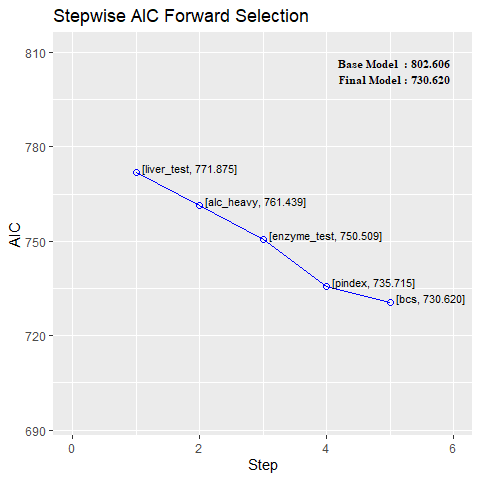

```r
model <- lm(y ~ ., data = surgical)
k <- ols_step_forward_aic(model)
plot(k)
```

#### Detailed Output

```r
# stepwise aic forward regression
model <- lm(y ~ ., data = surgical)
ols_step_forward_aic(model, details = TRUE)
```

```
Forward Selection Method
------------------------

Candidate Terms:

1. bcs
2. pindex
3. enzyme_test
4. liver_test
5. age
6. gender
7. alc_mod
8. alc_heavy


Step     => 0
Model    => y ~ 1
AIC      => 802.606

Initiating stepwise selection...

                       Table: Adding New Variables
-------------------------------------------------------------------------
Predictor      DF      AIC        SBC       SBIC        R2       Adj. R2
-------------------------------------------------------------------------
liver_test      1    771.875    777.842    616.009    0.45454     0.44405
enzyme_test     1    782.629    788.596    626.220    0.33435     0.32154
pindex          1    794.100    800.067    637.196    0.17680     0.16097
alc_heavy       1    794.301    800.268    637.389    0.17373     0.15784
bcs             1    797.697    803.664    640.655    0.12010     0.10318
alc_mod         1    802.828    808.795    645.601    0.03239     0.01378
gender          1    802.956    808.923    645.725    0.03009     0.01143
age             1    803.834    809.801    646.572    0.01420    -0.00476
-------------------------------------------------------------------------

Step     => 1
Added    => liver_test
Model    => y ~ liver_test
AIC      => 771.8753

```

[output cut: 121 more lines]

```
Residual      1833716.447        48      38202.426
Total         8369520.537        53
-----------------------------------------------------------------------

                                      Parameter Estimates
------------------------------------------------------------------------------------------------
      model         Beta    Std. Error    Std. Beta      t        Sig         lower       upper
------------------------------------------------------------------------------------------------
(Intercept)    -1178.330       208.682                 -5.647    0.000    -1597.914    -758.746
 liver_test       58.064        40.144        0.156     1.446    0.155      -22.652     138.779
  alc_heavy      317.848        71.634        0.314     4.437    0.000      173.818     461.878
enzyme_test        9.748         1.656        0.521     5.887    0.000        6.419      13.077
     pindex        8.924         1.808        0.380     4.935    0.000        5.288      12.559
        bcs       59.864        23.060        0.241     2.596    0.012       13.498     106.230
------------------------------------------------------------------------------------------------
```

### Stepwise AIC Backward Regression

Build regression model from a set of candidate predictor variables by removing predictors based on Akaike Information Criteria, in a stepwise manner until there is no variable left to remove any more. The model should include all the candidate predictor variables. If details is set to `TRUE`, each step is displayed.

#### Variable Selection

```r
# stepwise aic backward regression
model <- lm(y ~ ., data = surgical)
k <- ols_step_backward_aic(model)
k
```

```
                             Stepwise Summary
-------------------------------------------------------------------------
Step    Variable        AIC        SBC       SBIC        R2       Adj. R2
-------------------------------------------------------------------------
 0      Full Model    736.390    756.280    586.665    0.78184    0.74305
 1      alc_mod       734.407    752.308    583.884    0.78177    0.74856
 2      gender        732.494    748.406    581.290    0.78142    0.75351
 3      age           730.620    744.543    578.844    0.78091    0.75808
-------------------------------------------------------------------------

Final Model Output
------------------

                           Model Summary
-------------------------------------------------------------------
R                         0.884       RMSE                 184.276
R-Squared                 0.781       MSE                38202.426
Adj. R-Squared            0.758       Coef. Var             27.839
Pred R-Squared            0.700       AIC                  730.620
MAE                     137.656       SBC                  744.543
-------------------------------------------------------------------
 RMSE: Root Mean Square Error
 MSE: Mean Square Error
 MAE: Mean Absolute Error
 AIC: Akaike Information Criteria
 SBC: Schwarz Bayesian Criteria

                                 ANOVA
-----------------------------------------------------------------------
                   Sum of
                  Squares        DF    Mean Square      F         Sig.
-----------------------------------------------------------------------
Regression    6535804.090         5    1307160.818    34.217    0.0000
Residual      1833716.447        48      38202.426
Total         8369520.537        53
-----------------------------------------------------------------------

                                      Parameter Estimates
------------------------------------------------------------------------------------------------
      model         Beta    Std. Error    Std. Beta      t        Sig         lower       upper
------------------------------------------------------------------------------------------------
(Intercept)    -1178.330       208.682                 -5.647    0.000    -1597.914    -758.746
        bcs       59.864        23.060        0.241     2.596    0.012       13.498     106.230
     pindex        8.924         1.808        0.380     4.935    0.000        5.288      12.559
enzyme_test        9.748         1.656        0.521     5.887    0.000        6.419      13.077
 liver_test       58.064        40.144        0.156     1.446    0.155      -22.652     138.779
  alc_heavy      317.848        71.634        0.314     4.437    0.000      173.818     461.878
------------------------------------------------------------------------------------------------
```

#### Plot

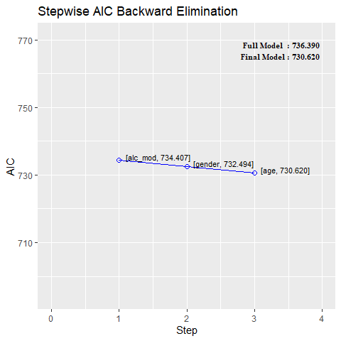

```r
model <- lm(y ~ ., data = surgical)
k <- ols_step_backward_aic(model)
plot(k)
```

#### Detailed Output

```r
# stepwise aic backward regression
model <- lm(y ~ ., data = surgical)
ols_step_backward_aic(model, details = TRUE)
```

```
Backward Elimination Method
---------------------------

Candidate Terms:

1. bcs
2. pindex
3. enzyme_test
4. liver_test
5. age
6. gender
7. alc_mod
8. alc_heavy


Step     => 0
Model    => y ~ bcs + pindex + enzyme_test + liver_test + age + gender + alc_mod + alc_heavy
AIC      => 736.3899

Initiating stepwise selection...

                   Table: Removing Existing Variables
------------------------------------------------------------------------
Predictor      DF      AIC        SBC       SBIC        R2       Adj. R2
------------------------------------------------------------------------
alc_mod         1    734.407    752.308    584.276    0.78177    0.74856
gender          1    734.478    752.379    584.323    0.78148    0.74823
age             1    734.544    752.445    584.367    0.78121    0.74792
liver_test      1    735.878    753.779    585.255    0.77574    0.74162
bcs             1    741.677    759.577    589.203    0.75032    0.71233
alc_heavy       1    749.210    767.111    594.541    0.71294    0.66926
pindex          1    756.624    774.525    600.014    0.67070    0.62059
enzyme_test     1    763.557    781.458    605.318    0.62559    0.56861
------------------------------------------------------------------------

Step     => 1
Removed  => alc_mod
Model    => y ~ bcs + pindex + enzyme_test + liver_test + age + gender + alc_heavy
AIC      => 734.4068

```

[output cut: 88 more lines]

```
Residual      1833716.447        48      38202.426
Total         8369520.537        53
-----------------------------------------------------------------------

                                      Parameter Estimates
------------------------------------------------------------------------------------------------
      model         Beta    Std. Error    Std. Beta      t        Sig         lower       upper
------------------------------------------------------------------------------------------------
(Intercept)    -1178.330       208.682                 -5.647    0.000    -1597.914    -758.746
        bcs       59.864        23.060        0.241     2.596    0.012       13.498     106.230
     pindex        8.924         1.808        0.380     4.935    0.000        5.288      12.559
enzyme_test        9.748         1.656        0.521     5.887    0.000        6.419      13.077
 liver_test       58.064        40.144        0.156     1.446    0.155      -22.652     138.779
  alc_heavy      317.848        71.634        0.314     4.437    0.000      173.818     461.878
------------------------------------------------------------------------------------------------
```

### Stepwise AIC Regression

Build regression model from a set of candidate predictor variables by entering and removing predictors based on Akaike Information Criteria, in a stepwise manner until there is no variable left to enter or remove any more. The model should include all the candidate predictor variables. If details is set to `TRUE`, each step is displayed.

#### Variable Selection

```r
# stepwise aic regression
model <- lm(y ~ ., data = surgical)
ols_step_both_aic(model)
```

```
                                Stepwise Summary
------------------------------------------------------------------------------
Step    Variable             AIC        SBC       SBIC        R2       Adj. R2
------------------------------------------------------------------------------
 0      Base Model         802.606    806.584    646.794    0.00000    0.00000
 1      liver_test (+)     771.875    777.842    616.009    0.45454    0.44405
 2      alc_heavy (+)      761.439    769.395    605.506    0.56674    0.54975
 3      enzyme_test (+)    750.509    760.454    595.297    0.65900    0.63854
 4      pindex (+)         735.715    747.649    582.943    0.75015    0.72975
 5      bcs (+)            730.620    744.543    579.638    0.78091    0.75808
------------------------------------------------------------------------------

Final Model Output
------------------

                           Model Summary
-------------------------------------------------------------------
R                         0.884       RMSE                 184.276
R-Squared                 0.781       MSE                38202.426
Adj. R-Squared            0.758       Coef. Var             27.839
Pred R-Squared            0.700       AIC                  730.620
MAE                     137.656       SBC                  744.543
-------------------------------------------------------------------
 RMSE: Root Mean Square Error
 MSE: Mean Square Error
 MAE: Mean Absolute Error
 AIC: Akaike Information Criteria
 SBC: Schwarz Bayesian Criteria

                                 ANOVA
-----------------------------------------------------------------------
                   Sum of
                  Squares        DF    Mean Square      F         Sig.
-----------------------------------------------------------------------
Regression    6535804.090         5    1307160.818    34.217    0.0000
Residual      1833716.447        48      38202.426
Total         8369520.537        53
-----------------------------------------------------------------------

                                      Parameter Estimates
------------------------------------------------------------------------------------------------
      model         Beta    Std. Error    Std. Beta      t        Sig         lower       upper
------------------------------------------------------------------------------------------------
(Intercept)    -1178.330       208.682                 -5.647    0.000    -1597.914    -758.746
 liver_test       58.064        40.144        0.156     1.446    0.155      -22.652     138.779
  alc_heavy      317.848        71.634        0.314     4.437    0.000      173.818     461.878
enzyme_test        9.748         1.656        0.521     5.887    0.000        6.419      13.077
     pindex        8.924         1.808        0.380     4.935    0.000        5.288      12.559
        bcs       59.864        23.060        0.241     2.596    0.012       13.498     106.230
------------------------------------------------------------------------------------------------
```

#### Plot

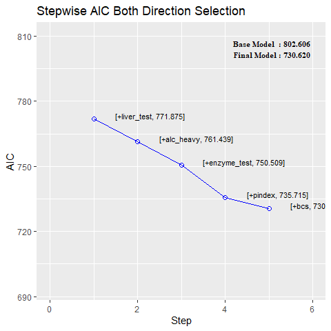

```r
model <- lm(y ~ ., data = surgical)
k <- ols_step_both_aic(model)
plot(k)
```

#### Detailed Output

```r
# stepwise aic regression
model <- lm(y ~ ., data = surgical)
ols_step_both_aic(model, details = TRUE)
```

```
Stepwise Selection Method
-------------------------

Candidate Terms:

1. bcs
2. pindex
3. enzyme_test
4. liver_test
5. age
6. gender
7. alc_mod
8. alc_heavy


Step     => 0
Model    => y ~ 1
AIC      => 802.606

Initiating stepwise selection...

                       Table: Adding New Variables
-------------------------------------------------------------------------
Predictor      DF      AIC        SBC       SBIC        R2       Adj. R2
-------------------------------------------------------------------------
bcs             1    797.697    803.664    640.655    0.12010     0.10318
pindex          1    794.100    800.067    637.196    0.17680     0.16097
enzyme_test     1    782.629    788.596    626.220    0.33435     0.32154
liver_test      1    771.875    777.842    616.009    0.45454     0.44405
age             1    803.834    809.801    646.572    0.01420    -0.00476
gender          1    802.956    808.923    645.725    0.03009     0.01143
alc_mod         1    802.828    808.795    645.601    0.03239     0.01378
alc_heavy       1    794.301    800.268    637.389    0.17373     0.15784
-------------------------------------------------------------------------

Step     => 1
Added    => liver_test
Model    => y ~ liver_test
AIC      => 771.8753

```

[output cut: 159 more lines]

```
Residual      1833716.447        48      38202.426
Total         8369520.537        53
-----------------------------------------------------------------------

                                      Parameter Estimates
------------------------------------------------------------------------------------------------
      model         Beta    Std. Error    Std. Beta      t        Sig         lower       upper
------------------------------------------------------------------------------------------------
(Intercept)    -1178.330       208.682                 -5.647    0.000    -1597.914    -758.746
 liver_test       58.064        40.144        0.156     1.446    0.155      -22.652     138.779
  alc_heavy      317.848        71.634        0.314     4.437    0.000      173.818     461.878
enzyme_test        9.748         1.656        0.521     5.887    0.000        6.419      13.077
     pindex        8.924         1.808        0.380     4.935    0.000        5.288      12.559
        bcs       59.864        23.060        0.241     2.596    0.012       13.498     106.230
------------------------------------------------------------------------------------------------
```

### Notes on stepwise

A fundamental problem with stepwise regression is that some real explanatory variables that have causal effects on the dependent variable may happen to not be statistically significant, while nuisance variables may be coincidentally significant. As a result, the model may fit the data well in-sample, but do poorly out-of-sample.

Many Big-Data researchers believe that, the larger the number of possible explanatory variables, the more useful is stepwise regression for selecting explanatory variables. The reality is that stepwise regression is less effective the larger the number of potential explanatory variables. Stepwise regression does not solve the Big-Data problem of too many explanatory variables. Big Data exacerbates the failings of stepwise regression. [reference](https://journalofbigdata.springeropen.com/articles/10.1186/s40537-018-0143-6)

## Residual Diagnostics

### Introduction

olsrr offers tools for detecting violation of standard regression assumptions. Here we take a look at residual diagnostics. The standard regression assumptions include the following about residuals/errors:

- The error has a normal distribution (normality assumption).
- The errors have mean zero.
- The errors have same but unknown variance (homoscedasticity assumption).
- The error are independent of each other (independent errors assumption).

### Residual QQ Plot

Graph for detecting violation of normality assumption.

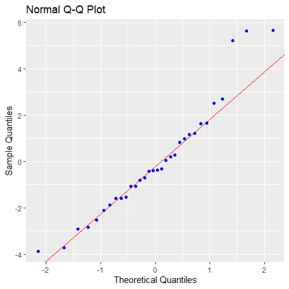

```r
model <- lm(mpg ~ disp + hp + wt + qsec, data = mtcars)
ols_plot_resid_qq(model)
```

### Residual Normality Test

Test for detecting violation of normality assumption.

```r
model <- lm(mpg ~ disp + hp + wt + qsec, data = mtcars)
ols_test_normality(model)
```

```
-----------------------------------------------
       Test             Statistic       pvalue
-----------------------------------------------
Shapiro-Wilk              0.9366         0.0600
Kolmogorov-Smirnov        0.1152         0.7464
Cramer-von Mises          2.8122         0.0000
Anderson-Darling          0.5859         0.1188
-----------------------------------------------
```

Correlation between observed residuals and expected residuals under normality.

```r
model <- lm(mpg ~ disp + hp + wt + qsec, data = mtcars)
ols_test_correlation(model)
```

```
[1] 0.970066
```

### Residual vs Fitted Values Plot

It is a scatter plot of residuals on the y axis and fitted values on the x axis to detect non-linearity, unequal error variances, and outliers.

**Characteristics of a well behaved residual vs fitted plot:**

- The residuals spread randomly around the 0 line indicating that the relationship is linear.
- The residuals form an approximate horizontal band around the 0 line indicating homogeneity of error variance.
- No one residual is visibly away from the random pattern of the residuals indicating that there are no outliers.

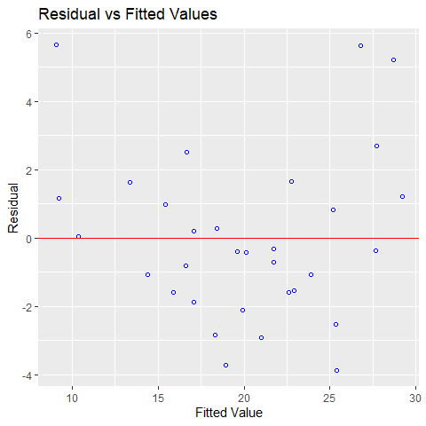

```r
model <- lm(mpg ~ disp + hp + wt + qsec, data = mtcars)
ols_plot_resid_fit(model)
```

### Residual Histogram

Histogram of residuals for detecting violation of normality assumption.

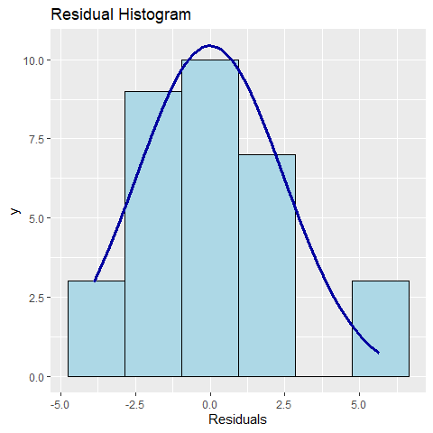

```r
model <- lm(mpg ~ disp + hp + wt + qsec, data = mtcars)
ols_plot_resid_hist(model)
```

## Heteroscedasticity

### Introduction

One of the assumptions made about residuals/errors in OLS regression is that the errors have the same but unknown variance. This is known as constant variance or homoscedasticity. When this assumption is violated, the problem is known as heteroscedasticity.

#### Consequences of Heteroscedasticity

- The OLS estimators and regression predictions based on them remains unbiased and consistent.
- The OLS estimators are no longer the BLUE (Best Linear Unbiased Estimators) because they are no longer efficient, so the regression predictions will be inefficient too.
- Because of the inconsistency of the covariance matrix of the estimated regression coefficients, the tests of hypotheses, (t-test, F-test) are no longer valid.

**olsrr** provides the following 4 tests for detecting heteroscedasticity:

- Bartlett Test
- Breusch Pagan Test
- Score Test
- F Test

### Bartlett Test

Bartlett’s test is used to test if variances across samples is equal. It is sensitive to departures from normality. The Levene test is an alternative test that is less sensitive to departures from normality.

You can perform the test using 2 continuous variables, one continuous and one grouping variable, a formula or a linear model.

#### Use grouping variable

```r
ols_test_bartlett(hsb, 'read', group_var = 'female')
```

```
    Bartlett's Test of Homogenity of Variances
------------------------------------------------
Ho: Variances are equal across groups
Ha: Variances are unequal for atleast two groups

        Test Summary
 ----------------------------
 DF            =    1
 Chi2          =    0.1866579
 Prob > Chi2   =    0.6657129
```

#### Using variables

```r
ols_test_bartlett(hsb, 'read', 'write')
```

```
    Bartlett's Test of Homogenity of Variances
------------------------------------------------
Ho: Variances are equal across groups
Ha: Variances are unequal for atleast two groups

        Data
 ---------------------
 Variables: read write

        Test Summary
 ----------------------------
 DF            =    1
 Chi2          =    1.222871
 Prob > Chi2   =    0.2687979
```

### Breusch Pagan Test

Breusch Pagan Test was introduced by Trevor Breusch and Adrian Pagan in 1979. It is used to test for heteroskedasticity in a linear regression model and assumes that the error terms are normally distributed. It tests whether the variance of the errors from a regression is dependent on the values of the independent variables. It is a $\chi^{2}$ test.

You can perform the test using the fitted values of the model, the predictors in the model and a subset of the independent variables. It includes options to perform multiple tests and p value adjustments. The options for p value adjustments include Bonferroni, Sidak and Holm’s method.

#### Use fitted values of the model

```r
model <- lm(mpg ~ disp + hp + wt + drat, data = mtcars)
ols_test_breusch_pagan(model)
```

```
 Breusch Pagan Test for Heteroskedasticity
 -----------------------------------------
 Ho: the variance is constant
 Ha: the variance is not constant

             Data
 -------------------------------
 Response : mpg
 Variables: fitted values of mpg

       Test Summary
 ---------------------------
 DF            =    1
 Chi2          =    1.429672
 Prob > Chi2   =    0.231818
```

#### Use independent variables of the model

```r
model <- lm(mpg ~ disp + hp + wt + drat, data = mtcars)
ols_test_breusch_pagan(model, rhs = TRUE)
```

```
 Breusch Pagan Test for Heteroskedasticity
 -----------------------------------------
 Ho: the variance is constant
 Ha: the variance is not constant

           Data
 --------------------------
 Response : mpg
 Variables: disp hp wt drat

        Test Summary
 ----------------------------
 DF            =    4
 Chi2          =    1.513808
 Prob > Chi2   =    0.8241927
```

#### Use independent variables of the model and perform multiple tests

```r
model <- lm(mpg ~ disp + hp + wt + drat, data = mtcars)
ols_test_breusch_pagan(model, rhs = TRUE, multiple = TRUE)
```

```
 Breusch Pagan Test for Heteroskedasticity
 -----------------------------------------
 Ho: the variance is constant
 Ha: the variance is not constant

           Data
 --------------------------
 Response : mpg
 Variables: disp hp wt drat

        Test Summary (Unadjusted p values)
 ----------------------------------------------
  Variable           chi2       df        p
 ----------------------------------------------
  disp             1.2355345     1    0.2663334
  hp               0.9209878     1    0.3372157
  wt               1.2529988     1    0.2629805
  drat             1.1668486     1    0.2800497
 ----------------------------------------------
  simultaneous     1.5138083     4    0.8241927
 ----------------------------------------------
```

#### Bonferroni p value Adjustment

```r
model <- lm(mpg ~ disp + hp + wt + drat, data = mtcars)
ols_test_breusch_pagan(model, rhs = TRUE, multiple = TRUE, p.adj = 'bonferroni')
```

```
 Breusch Pagan Test for Heteroskedasticity
 -----------------------------------------
 Ho: the variance is constant
 Ha: the variance is not constant

           Data
 --------------------------
 Response : mpg
 Variables: disp hp wt drat

        Test Summary (Bonferroni p values)
 ----------------------------------------------
  Variable           chi2       df        p
 ----------------------------------------------
  disp             1.2355345     1    1.0000000
  hp               0.9209878     1    1.0000000
  wt               1.2529988     1    1.0000000
  drat             1.1668486     1    1.0000000
 ----------------------------------------------
  simultaneous     1.5138083     4    0.8241927
 ----------------------------------------------
```

#### Sidak p value Adjustment

```r
model <- lm(mpg ~ disp + hp + wt + drat, data = mtcars)
ols_test_breusch_pagan(model, rhs = TRUE, multiple = TRUE, p.adj = 'sidak')
```

```
 Breusch Pagan Test for Heteroskedasticity
 -----------------------------------------
 Ho: the variance is constant
 Ha: the variance is not constant

           Data
 --------------------------
 Response : mpg
 Variables: disp hp wt drat

          Test Summary (Sidak p values)
 ----------------------------------------------
  Variable           chi2       df        p
 ----------------------------------------------
  disp             1.2355345     1    0.7102690
  hp               0.9209878     1    0.8070305
  wt               1.2529988     1    0.7049362
  drat             1.1668486     1    0.7313356
 ----------------------------------------------
  simultaneous     1.5138083     4    0.8241927
 ----------------------------------------------
```

#### Holm’s p value Adjustment

```r
model <- lm(mpg ~ disp + hp + wt + drat, data = mtcars)
ols_test_breusch_pagan(model, rhs = TRUE, multiple = TRUE, p.adj = 'holm')
```

```
 Breusch Pagan Test for Heteroskedasticity
 -----------------------------------------
 Ho: the variance is constant
 Ha: the variance is not constant

           Data
 --------------------------
 Response : mpg
 Variables: disp hp wt drat

          Test Summary (Holm's p values)
 ----------------------------------------------
  Variable           chi2       df        p
 ----------------------------------------------
  disp             1.2355345     1    0.7990002
  hp               0.9209878     1    0.3372157
  wt               1.2529988     1    1.0000000
  drat             1.1668486     1    0.5600994
 ----------------------------------------------
  simultaneous     1.5138083     4    0.8241927
 ----------------------------------------------
```

### Score Test

Test for heteroskedasticity under the assumption that the errors are independent and identically distributed (i.i.d.). You can perform the test using the fitted values of the model, the predictors in the model and a subset of the independent variables.

#### Use fitted values of the model

```r
model <- lm(mpg ~ disp + hp + wt + qsec, data = mtcars)
ols_test_score(model)
```

```
 Score Test for Heteroskedasticity
 ---------------------------------
 Ho: Variance is homogenous
 Ha: Variance is not homogenous

 Variables: fitted values of mpg

        Test Summary
 ----------------------------
 DF            =    1
 Chi2          =    0.5163959
 Prob > Chi2   =    0.4723832
```

#### Use independent variables of the model

```r
model <- lm(mpg ~ disp + hp + wt + qsec, data = mtcars)
ols_test_score(model, rhs = TRUE)
```

```
 Score Test for Heteroskedasticity
 ---------------------------------
 Ho: Variance is homogenous
 Ha: Variance is not homogenous

 Variables: disp hp wt qsec

        Test Summary
 ----------------------------
 DF            =    4
 Chi2          =    2.039404
 Prob > Chi2   =    0.7285114
```

#### Specify variables

```r
model <- lm(mpg ~ disp + hp + wt + qsec, data = mtcars)
ols_test_score(model, vars = c('disp', 'hp'))
```

```
 Score Test for Heteroskedasticity
 ---------------------------------
 Ho: Variance is homogenous
 Ha: Variance is not homogenous

 Variables: disp hp

        Test Summary
 ----------------------------
 DF            =    2
 Chi2          =    0.9983196
 Prob > Chi2   =    0.6070405
```

### F Test

F Test for heteroskedasticity under the assumption that the errors are independent and identically distributed (i.i.d.). You can perform the test using the fitted values of the model, the predictors in the model and a subset of the independent variables.

#### Use fitted values of the model

```r
model <- lm(mpg ~ disp + hp + wt + qsec, data = mtcars)
ols_test_f(model)
```

```
 F Test for Heteroskedasticity
 -----------------------------
 Ho: Variance is homogenous
 Ha: Variance is not homogenous

 Variables: fitted values of mpg

      Test Summary
 -------------------------
 Num DF     =    1
 Den DF     =    30
 F          =    0.4920617
 Prob > F   =    0.4884154
```

#### Use independent variables of the model

```r
model <- lm(mpg ~ disp + hp + wt + qsec, data = mtcars)
ols_test_f(model, rhs = TRUE)
```

```
 F Test for Heteroskedasticity
 -----------------------------
 Ho: Variance is homogenous
 Ha: Variance is not homogenous

 Variables: disp hp wt qsec

      Test Summary
 -------------------------
 Num DF     =    4
 Den DF     =    27
 F          =    0.4594694
 Prob > F   =    0.7647271
```

#### Specify variables

```r
model <- lm(mpg ~ disp + hp + wt + qsec, data = mtcars)
ols_test_f(model, vars = c('disp', 'hp'))
```

```
 F Test for Heteroskedasticity
 -----------------------------
 Ho: Variance is homogenous
 Ha: Variance is not homogenous

 Variables: disp hp

      Test Summary
 -------------------------
 Num DF     =    2
 Den DF     =    29
 F          =    0.4669306
 Prob > F   =    0.631555
```

## Measures of Influence

### Introduction

It is possible for a single observation to have a great influence on the results of a regression analysis. It is therefore important to detect influential observations and to take them into consideration when interpreting the results.

**olsrr** offers the following tools to detect influential observations:

- Cook’s D Bar Plot
- Cook’s D Chart
- DFBETAs Panel
- DFFITs Plot
- Studentized Residual Plot
- Standardized Residual Chart
- Studentized Residuals vs Leverage Plot
- Deleted Studentized Residual vs Fitted Values Plot
- Hadi Plot
- Potential Residual Plot

#### Cook’s D Bar Plot

Bar Plot of Cook’s distance to detect observations that strongly influence fitted values of the model. Cook’s distance was introduced by American statistician R Dennis Cook in 1977. It is used to identify influential data points. It depends on both the residual and leverage i.e it takes it account both the **x** value and **y** value of the observation.

**Steps to compute Cook’s distance:**

- delete observations one at a time.
- refit the regression model on remaining $(n - 1)$ observations
- examine how much all of the fitted values change when the ith observation is deleted.

A data point having a large cook’s d indicates that the data point strongly influences the fitted values.

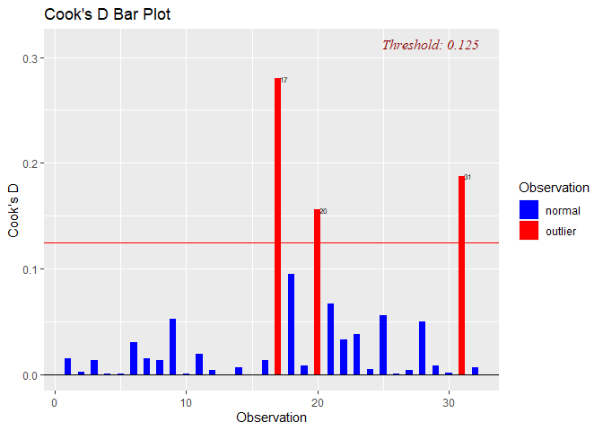

```r
model <- lm(mpg ~ disp + hp + wt + qsec, data = mtcars)
ols_plot_cooksd_bar(model)
```

### Cook’s D Chart

Chart of Cook’s distance to detect observations that strongly influence fitted values of the model.

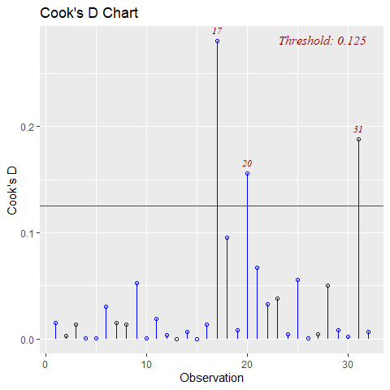

```r
model <- lm(mpg ~ disp + hp + wt + qsec, data = mtcars)
ols_plot_cooksd_chart(model)
```

### DFBETAs Panel

DFBETA measures the difference in each parameter estimate with and without the influential point. There is a DFBETA for each data point i.e if there are n observations and k variables, there will be $n * k$ DFBETAs. In general, large values of DFBETAS indicate observations that are influential in estimating a given parameter. Belsley, Kuh, and Welsch recommend 2 as a general cutoff value to indicate influential observations and $\frac{2}{\sqrt{n}}$ as a size-adjusted cutoff.

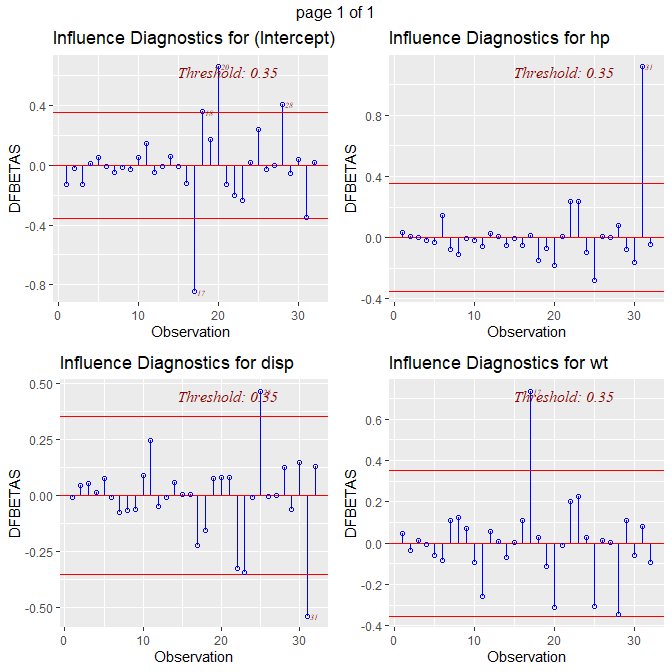

```r
model <- lm(mpg ~ disp + hp + wt, data = mtcars)
ols_plot_dfbetas(model)
```

### DFFITS Plot

Proposed by Welsch and Kuh (1977). It is the scaled difference between the $i^{th}$ fitted value obtained from the full data and the $i^{th}$ fitted value obtained by deleting the $i^{th}$ observation. DFFIT - difference in fits, is used to identify influential data points. It quantifies the number of standard deviations that the fitted value changes when the ith data point is omitted.

**Steps to compute DFFITs:**

- delete observations one at a time.
- refit the regression model on remaining $ {n - 1} $ observations
- examine how much all of the fitted values change when the ith observation is deleted.

An observation is deemed influential if the absolute value of its DFFITS value is greater than:

$${2}*{\frac{\sqrt{(p + 1)}}{(n - p -1)}}$$

where n is the number of observations and p is the number of predictors including intercept.

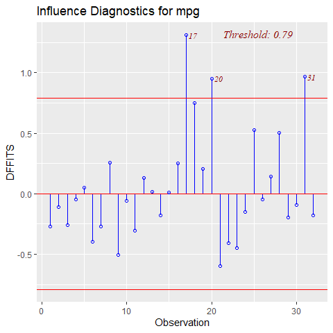

```r
model <- lm(mpg ~ disp + hp + wt + qsec, data = mtcars)
ols_plot_dffits(model)
```

### Studentized Residual Plot

Plot for detecting outliers. Studentized deleted residuals (or externally studentized residuals) is the deleted residual divided by its estimated standard deviation. Studentized residuals are going to be more effective for detecting outlying Y observations than standardized residuals. If an observation has an externally studentized residual that is larger than 3 (in absolute value) we can call it an outlier.

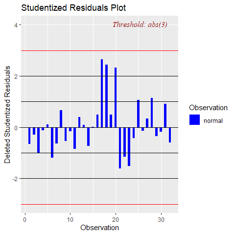

```r
model <- lm(mpg ~ disp + hp + wt + qsec, data = mtcars)
ols_plot_resid_stud(model)
```

### Standardized Residual Chart

Chart for detecting outliers. Standardized residual (internally studentized) is the residual divided by estimated standard deviation.

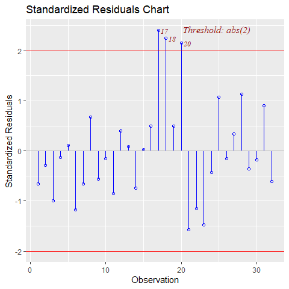

```r
model <- lm(mpg ~ disp + hp + wt + qsec, data = mtcars)
ols_plot_resid_stand(model)
```

### Studentized Residuals vs Leverage Plot

Graph for detecting influential observations.

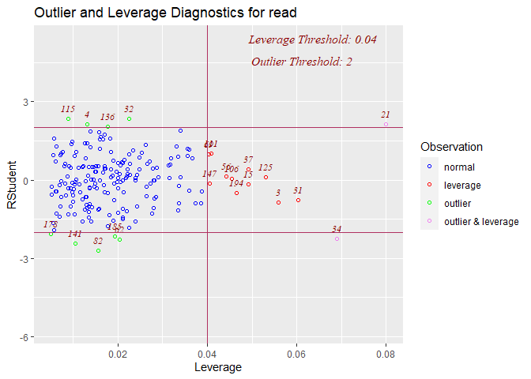

```r
model <- lm(read ~ write + math + science, data = hsb)
ols_plot_resid_lev(model)
```

### Deleted Studentized Residual vs Fitted Values Plot

Graph for detecting outliers.

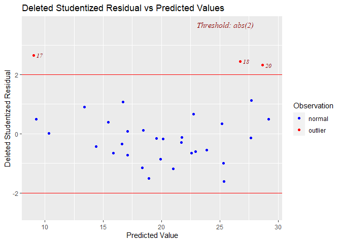

```r
model <- lm(mpg ~ disp + hp + wt + qsec, data = mtcars)
ols_plot_resid_stud_fit(model)
```

### Hadi Plot

Hadi’s measure of influence based on the fact that influential observations can be present in either the response variable or in the predictors or both. The plot is used to detect influential observations based on Hadi’s measure.

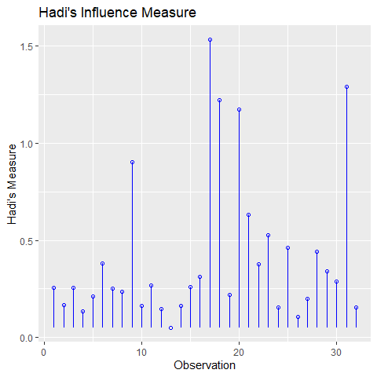

```r
model <- lm(mpg ~ disp + hp + wt + qsec, data = mtcars)
ols_plot_hadi(model)
```

### Potential Residual Plot

Plot to aid in classifying unusual observations as high-leverage points, outliers, or a combination of both.

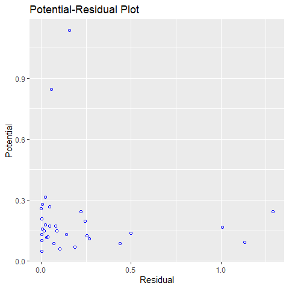

```r
model <- lm(mpg ~ disp + hp + wt + qsec, data = mtcars)
ols_plot_resid_pot(model)
```

## Collinearity Diagnostics, Model Fit & Variable Contribution

### Collinearity Diagnostics

Collinearity implies two variables are near perfect linear combinations of one another. Multicollinearity involves more than two variables. In the presence of multicollinearity, regression estimates are unstable and have high standard errors.

#### VIF

Variance inflation factors measure the inflation in the variances of the parameter estimates due to collinearities that exist among the predictors. It is a measure of how much the variance of the estimated regression coefficient $\beta_{k}$ is “inflated” by the existence of correlation among the predictor variables in the model. A VIF of 1 means that there is no correlation among the kth predictor and the remaining predictor variables, and hence the variance of $\beta_{k}$ is not inflated at all. The general rule of thumb is that VIFs exceeding 4 warrant further investigation, while VIFs exceeding 10 are signs of serious multicollinearity requiring correction.

Steps to calculate VIF:

- Regress the $k^{th}$ predictor on rest of the predictors in the model.
- Compute the ${R}^{2}_{k}$

$$VIF = \frac{1}{1 - {R}^{2}_{k}} = \frac{1}{Tolerance}$$

```r
model <- lm(mpg ~ disp + hp + wt + qsec, data = mtcars)
ols_vif_tol(model)
```

| Variables | Tolerance | VIF |
| --- | --- | --- |
| disp | 0.1252279 | 7.985439 |
| hp | 0.1935450 | 5.166758 |
| wt | 0.1445726 | 6.916942 |
| qsec | 0.3191708 | 3.133119 |

#### Tolerance

Percent of variance in the predictor that cannot be accounted for by other predictors.

Steps to calculate tolerance:

- Regress the $k^{th}$ predictor on rest of the predictors in the model.
- Compute the ${R}^{2}_{k}$

$$Tolerance = 1 - {R}^{2}_{k}$$

#### Condition Index

Most multivariate statistical approaches involve decomposing a correlation matrix into linear combinations of variables. The linear combinations are chosen so that the first combination has the largest possible variance (subject to some restrictions we won’t discuss), the second combination has the next largest variance, subject to being uncorrelated with the first, the third has the largest possible variance, subject to being uncorrelated with the first and second, and so forth. The variance of each of these linear combinations is called an eigenvalue. Collinearity is spotted by finding 2 or more variables that have large proportions of variance (.50 or more) that correspond to large condition indices. A rule of thumb is to label as large those condition indices in the range of 30 or larger.

```r
model <- lm(mpg ~ disp + hp + wt + qsec, data = mtcars)
ols_eigen_cindex(model)
```

| Eigenvalue | Condition Index | intercept | disp | hp | wt | qsec |
| --- | --- | --- | --- | --- | --- | --- |
| 4.721487187 | 1.000000 | 0.000123237 | 0.001132468 | 0.001413094 | 0.0005253393 | 0.0001277169 |
| 0.216562203 | 4.669260 | 0.002617424 | 0.036811051 | 0.027751289 | 0.0002096014 | 0.0046789491 |
| 0.050416837 | 9.677242 | 0.001656551 | 0.120881424 | 0.392366164 | 0.0377028008 | 0.0001952599 |
| 0.010104757 | 21.616057 | 0.025805998 | 0.777260487 | 0.059594623 | 0.7017528428 | 0.0024577686 |
| 0.001429017 | 57.480524 | 0.969796790 | 0.063914571 | 0.518874831 | 0.2598094157 | 0.9925403056 |

#### Collinearity Diagnostics

```r
model <- lm(mpg ~ disp + hp + wt + qsec, data = mtcars)
ols_coll_diag(model)
```

```
Tolerance and Variance Inflation Factor
---------------------------------------
```

| Variables | Tolerance | VIF |
| --- | --- | --- |
| disp | 0.1252279 | 7.985439 |
| hp | 0.1935450 | 5.166758 |
| wt | 0.1445726 | 6.916942 |
| qsec | 0.3191708 | 3.133119 |

```
Eigenvalue and Condition Index
------------------------------
```

| Eigenvalue | Condition Index | intercept | disp | hp | wt | qsec |
| --- | --- | --- | --- | --- | --- | --- |
| 4.721487187 | 1.000000 | 0.000123237 | 0.001132468 | 0.001413094 | 0.0005253393 | 0.0001277169 |
| 0.216562203 | 4.669260 | 0.002617424 | 0.036811051 | 0.027751289 | 0.0002096014 | 0.0046789491 |
| 0.050416837 | 9.677242 | 0.001656551 | 0.120881424 | 0.392366164 | 0.0377028008 | 0.0001952599 |
| 0.010104757 | 21.616057 | 0.025805998 | 0.777260487 | 0.059594623 | 0.7017528428 | 0.0024577686 |
| 0.001429017 | 57.480524 | 0.969796790 | 0.063914571 | 0.518874831 | 0.2598094157 | 0.9925403056 |

### Model Fit Assessment

#### Residual Fit Spread Plot

Plot to detect non-linearity, influential observations and outliers. Consists of side-by-side quantile plots of the centered fit and the residuals. It shows how much variation in the data is explained by the fit and how much remains in the residuals. For inappropriate models, the spread of the residuals in such a plot is often greater than the spread of the centered fit.

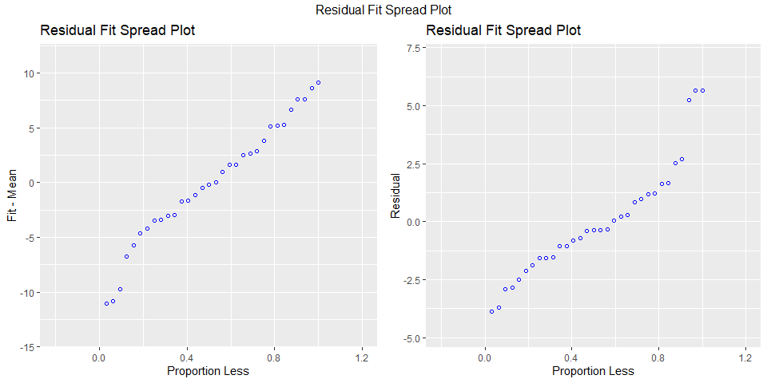

```r
model <- lm(mpg ~ disp + hp + wt + qsec, data = mtcars)
ols_plot_resid_fit_spread(model)
```

#### Part & Partial Correlations

##### Correlations

Relative importance of independent variables in determining **Y**. How much each variable uniquely contributes to $R^{2}$ over and above that which can be accounted for by the other predictors.

##### Zero Order

Pearson correlation coefficient between the dependent variable and the independent variables.

##### Part

Unique contribution of independent variables. How much $R^{2}$ will decrease if that variable is removed from the model?

##### Partial

How much of the variance in **Y**, which is not estimated by the other independent variables in the model, is estimated by the specific variable?

```r
model <- lm(mpg ~ disp + hp + wt + qsec, data = mtcars)
ols_correlations(model)
```

```
               Correlations
-------------------------------------------
Variable    Zero Order    Partial     Part
-------------------------------------------
disp            -0.848      0.048     0.019
hp              -0.776     -0.224    -0.093
wt              -0.868     -0.574    -0.285
qsec             0.419      0.219     0.091
-------------------------------------------
```

#### Observed vs Predicted Plot

Plot of observed vs fitted values to assess the fit of the model. Ideally, all your points should be close to a regressed diagonal line. Draw such a diagonal line within your graph and check out where the points lie. If your model had a high R Square, all the points would be close to this diagonal line. The lower the R Square, the weaker the Goodness of fit of your model, the more foggy or dispersed your points are from this diagonal line.

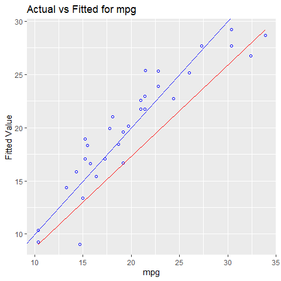

```r
model <- lm(mpg ~ disp + hp + wt + qsec, data = mtcars)
ols_plot_obs_fit(model)
```

#### Lack of Fit F Test

Assess how much of the error in prediction is due to lack of model fit. The residual sum of squares resulting from a regression can be decomposed into 2 components:

- Due to lack of fit
- Due to random variation

If most of the error is due to lack of fit and not just random error, the model should be discarded and a new model must be built. The lack of fit F test works only with simple linear regression. Moreover, it is important that the data contains repeat observations i.e. replicates for at least one of the values of the predictor x. This test generally only applies to datasets with plenty of replicates.

```r
model <- lm(mpg ~ disp, data = mtcars)
ols_pure_error_anova(model)
```

```
Lack of Fit F Test
-----------------
Response :   mpg
Predictor:   disp

                      Analysis of Variance Table
----------------------------------------------------------------------
                DF     Sum Sq     Mean Sq     F Value        Pr(>F)
----------------------------------------------------------------------
disp             1    808.8885    808.8885    314.0095    1.934413e-17
Residual        30    317.1587    10.57196
 Lack of fit    25    304.2787    12.17115    4.724824      0.04563623
 Pure Error      5       12.88       2.576
----------------------------------------------------------------------
```

#### Diagnostics Panel

Panel of plots for regression diagnostics